# SBC Cooperative Program Analysis

Grady Lynn

7/07/2021

## Introduction

This is a small personal data analysis project focused on the Cooperative Program of the Southern Baptist Convention.

The [Southern Baptist Convention](https://www.sbc.net) (SBC) has over 45,000 member churches and over 5,000,000 in weekly worship attendance<sup>[1](https://www.sbc.net/about/what-we-do/fast-facts/)</sup>, making it the largest Protestant and second-largest Christian denomination in the United States (behind Roman Catholicism).<sup>[2](https://en.wikipedia.org/wiki/Southern_Baptist_Convention)</sup>

The [Cooperative Program](https://www.sbc.net/missions/the-cooperative-program/) (CP) is the SBC’s **unified national giving plan for Southern Baptist ministries and missions**. Every SBC church decides how much of its designated gifts to send on to the Cooperative Program. This amount is then forwarded to that church’s state baptist convention. Each state convention then decides how much money stays in the state for local ministry and how much is forwarded to the national Cooperative Program. The national Cooperative Program then budgets these resources towards national programs.

The most notable national CP budget items include:

- **Missions**
  - The International Mission Board (IMB)
  - The North American Mission Board (NAMB)
- **Baptist Theological Seminaries**
  - Golden Gate Seminary *(near San Francisco, CA)*
  - Midwestern Seminary *(Kansas City, MO)*
  - New Orleans Seminary *(New Orleans, LA)*
  - Southeastern Seminary *(Wake Forest, NC)*
  - Southern Seminary *(Louisville, KY)*
  - Southwestern Seminary *(Fort Worth, TX)*
- **SBC Operating Expenses**

The national Cooperative Program releases [reports](https://www.sbc.net/missions/the-cooperative-program/reports/monthly/) detailing the receipts from each state convention and the budget items for each month. This data has been scraped and consolidated [here](https://github.com/gradylynn/sbc-cooperative-program-giving/tree/main/data) using original code that can be found [here](https://github.com/gradylynn/sbc-cooperative-program-giving).

This project is intended as a general overview of the SBC’s monthly Cooperative Program budget and receipts (since October 2012).

## Data Overview

Here are some charts which give an overview of the CP reporting data. There are **two parts** which will be examined in turn:

1. **Budget** (amounts budgeted towards various missions and ministries)
2. **Receipts** (amounts received from state conventions)

There are also **two different types of gifts & spending**:

1. **Designated Spending** - This comes from gifts that are designated for a specific ministry. For example, there is an annual Christmas giving campaign (the Lottie Moon Christmas Offering) that goes specifically to the International Mission Board.
2. **Allocated Spending** - For all non-designated gifts, the Cooperative Program can decide how much to allocate to various programs.

### CP Budget Overview

Here is a first look at the national CP budget.

#### Overall

In this overall budget overview, the CP budget is divided into 4 broad categories:

1. International Mission Board (IMB)
2. North American Mission Board (NAMB)
3. Seminaries (all 6 seminaries combined)
4. Other

A note on the yearly aggregations: the ‘yearly’ charts below shows the **average monthly spending for each year**, not fiscal year (SBC fiscal years are Oct-Sep). Because the data goes from Oct 2012 to present day, there may be partial years (and unexpected patterns) at the beginning and end of the yearly charts.

##### Total Budget (Allocations + Designations)

###### Monthly Total Budget

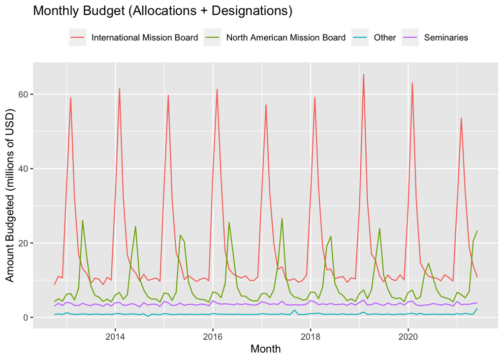

###### Yearly Total Budget

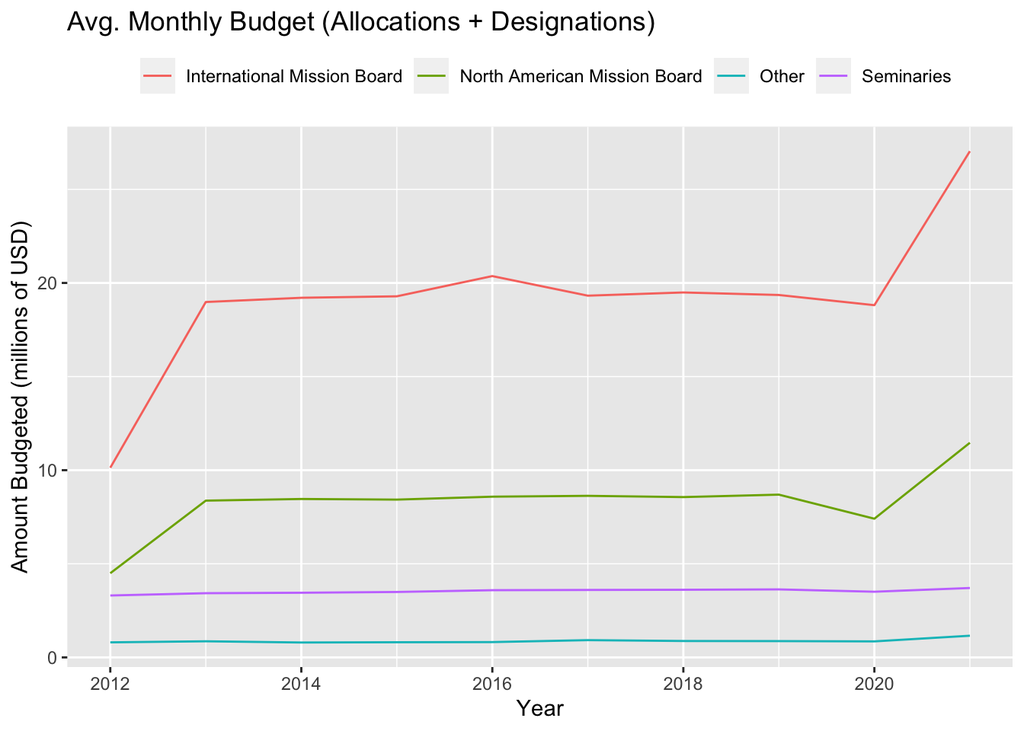

##### Allocations

###### Monthly Allocations

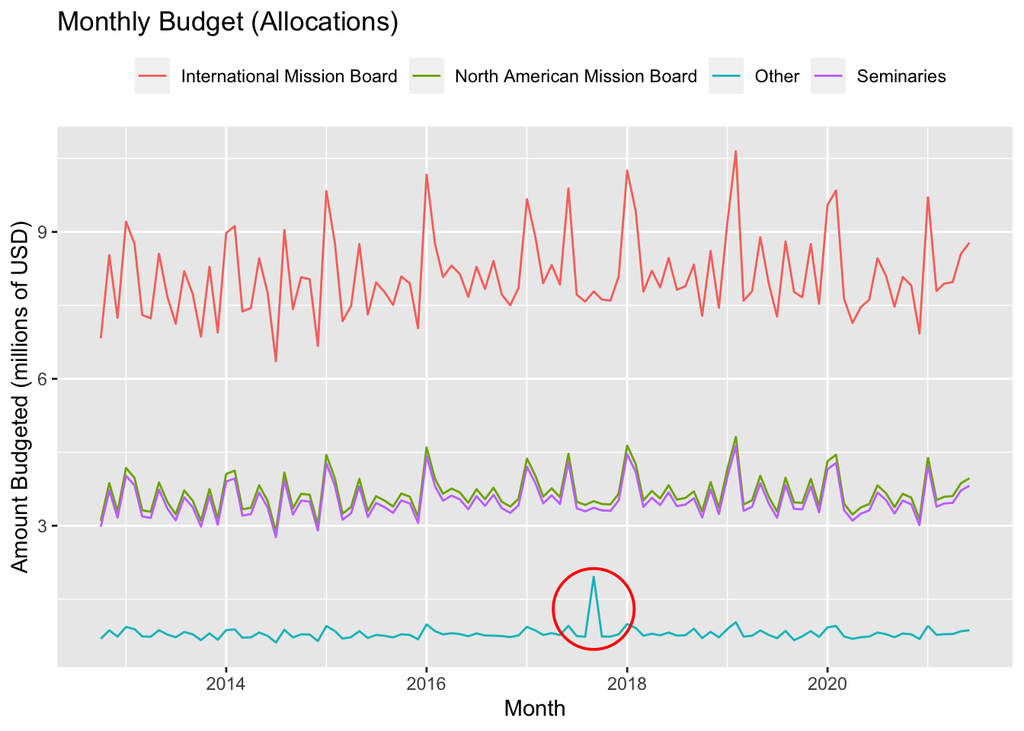

This chart displays a noticeable outlier (circled above): In September 2017, the non-seminary-or-mission-board budget was considerably higher than all other months. On the report for that month, there is a budget line-item that appears nowhere else in the data: $1.25 million for **“NAMB - Disaster Relief”**. In the wake of hurricanes Irma, Harvey, and Maria, the SBC Executive Committee voted to designate $1.25 million of allocation budget overage towards disaster relief in Florida and Texas.<sup>[3](https://www.baptistpress.com/resource-library/news/cp-overage-reallocation-to-aid-hurricane-survivors/)</sup>

###### Yearly Allocations

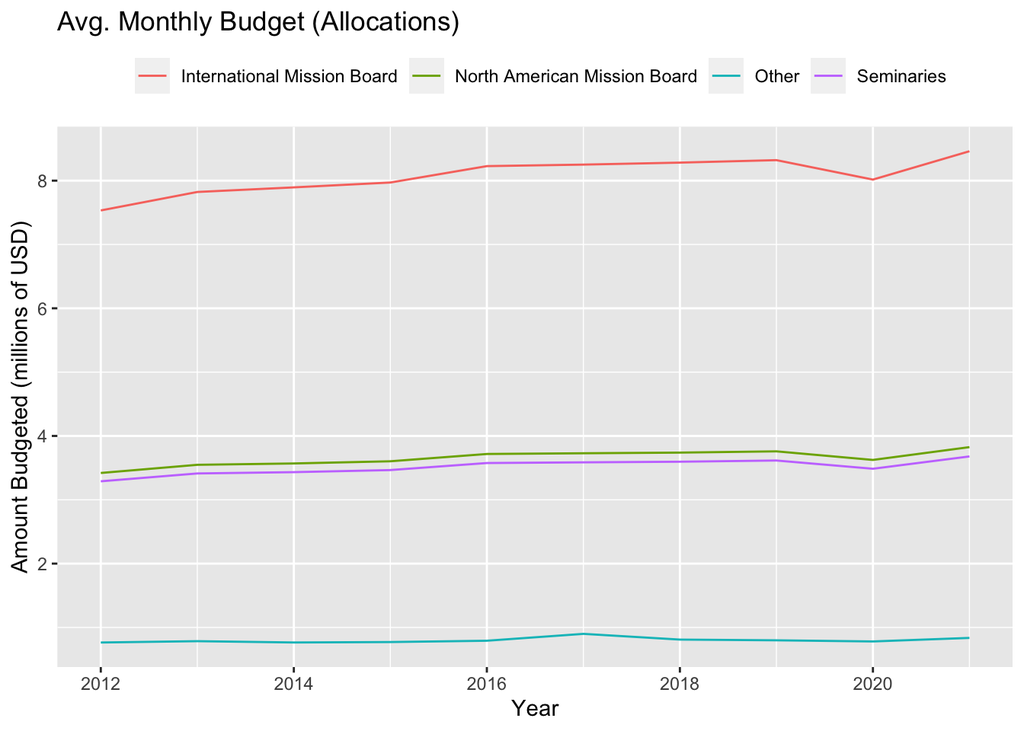

##### Designations

###### Monthly Designations

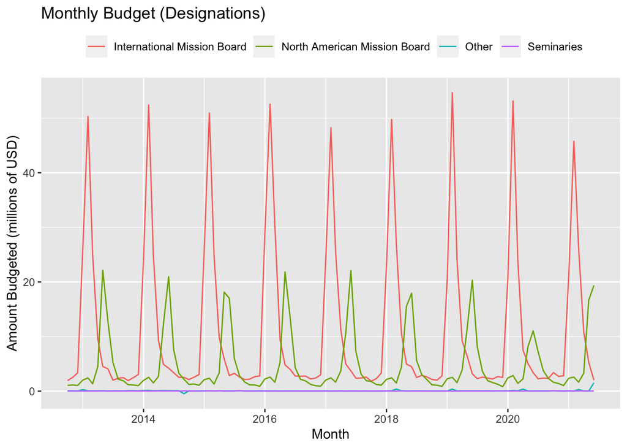

Note that the IMB and NAMB receive a massive chunk of funding from seasonal offerings dedicated specifically to their ministries (the [Lottie Moon Christmas Offering](https://www.imb.org/lottie-moon-christmas-offering/) and the [Annie Armstrong Easter Offering](https://www.anniearmstrong.com) respectively).

###### Yearly Designations

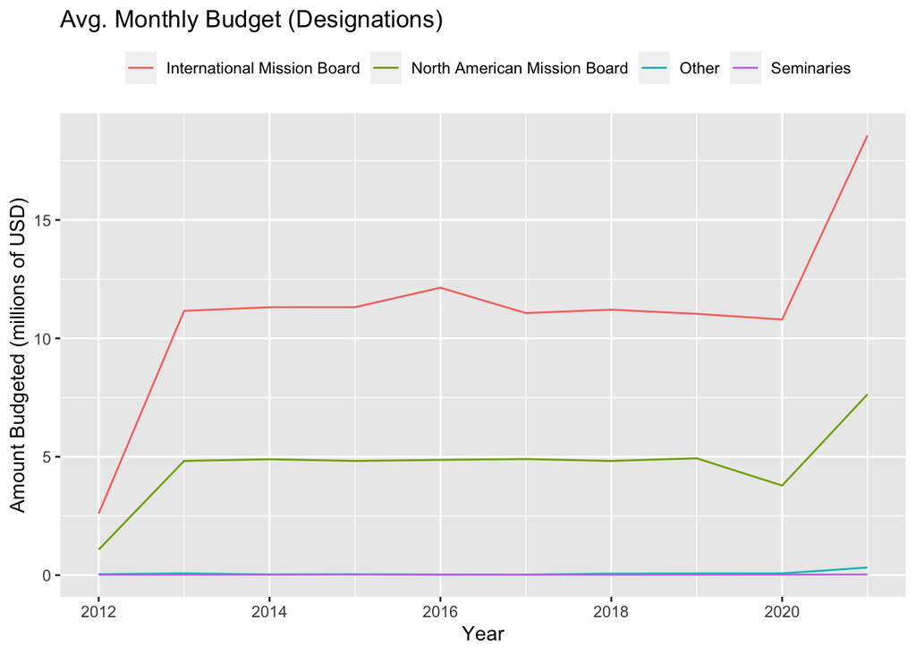

#### Seminaries

This section zooms in on the seminary spending of the cooperative program. Note (from the previous charts) that the vast majority of these seminaries’ budgets are allocated, not designated.

##### Monthly Seminary Budget

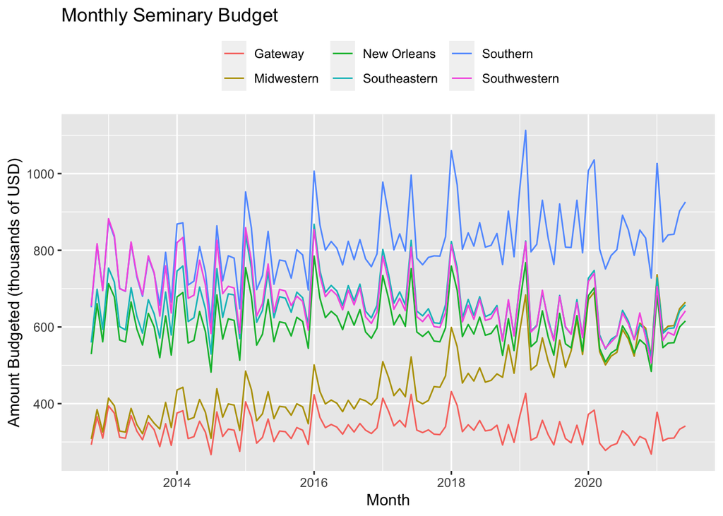

##### Yearly Seminary Budget

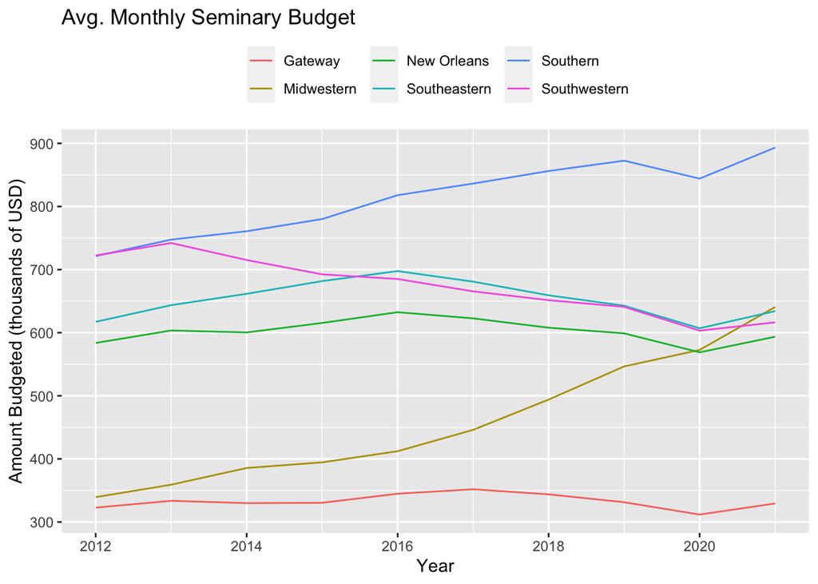

#### Other Spending

The majority of the Cooperative Program budget goes towards Mission Boards and Seminaries. This section will give an overview of all other reported spending (the majority of which is allocated, not designated). These “other” items include:

1. **SBC Executive Committee and SBC Operating** (*SBC EC & Operating*)
   - Budgeted for SBC Executive Committee, Staff, and Operating Costs.
2. **Ethics and Religious Liberty Commission** (*ERLC*)
   - The public policy arm of the SBC.
3. **GuideStone Financial Resources** (*GuideStone*)
   - Retirement solutions & insurance coverage for full-time ministers.<sup>[4](https://www.guidestone.org/About-Us)</sup>
4. **Historical Library and Archives** (*Library & Archives*)
   - A center to support the study of Baptist history located in the fourth floor of the Southern Baptist Convention Building.<sup>[5](https://sbhla.org)</sup>
5. **SBC Executive Committee - Vision 2025** (*Vision 2025*)
   - The SBC’s strategic plan aiming for various ministry goals by 2025.<sup>[6](https://www.sbc.net/vision-2025)</sup>
6. **Miscellaneous**
   - This budget item has stopped occurring in the reports since October 2020.

##### One-Time Budget Items

| year | month | ministry | allocated | designated |
| --- | --- | --- | --- | --- |
| 2018 | Sep | EC/SBC - SBC Presidential Study on Abuse | 250000 | 0 |
| 2017 | Sep | NAMB - Disaster Relief | 1250000 | 0 |

These few budget items only occur once in the data’s timeframe.

1. **NAMB - Disaster Relief** *(September 2017)*  
   This is discussed in the *Monthly Allocations* chart above. In the wake of hurricanes Irma, Harvey, and Maria, the SBC Executive Committee voted to designate $1.25 million of allocation budget overage towards disaster relief in Florida and Texas.<sup>[3](https://www.baptistpress.com/resource-library/news/cp-overage-reallocation-to-aid-hurricane-survivors/)</sup>
2. **EC/SBC - SBC Presidential Study on Abuse** *(September 2018)*  
   In 2018, the SBC Executive Committee approved funding for presidential initiative to address sexual abuse in Southern Baptist churches.<sup>[7](https://www.baptistpress.com/resource-library/sbc-life-articles/sbc-presidential-sexual-abuse-study-launched-funded/)</sup> The initiative resulted in a [June 2019 report](https://caringwell.com/report/) and the [**Caring Well Challenge**](https://caringwell.com), an program for assisting churches in preventing abuse and caring for abuse survivors.

These one-time budget items will be excluded from the other charts in this section.

##### Monthly Other Budget

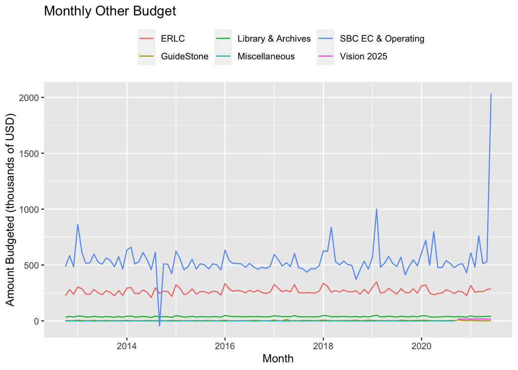

Because this data reports CP budgeting, not necessarily actual spending, there are occasional budget corrections due to overages or deficits. For example, in September 2014 (at the end of the fiscal year), a large amount of money was designated away from the SBC operating budget, leading to the noticeable dip in the top line of the chart above.

This chart also reveals a massive amount (more than $1.5 million) of designated funding towards SBC Operations for June 2021. A future iteration of this analysis will investigate that unexpected amount.

##### Yearly Other Budget

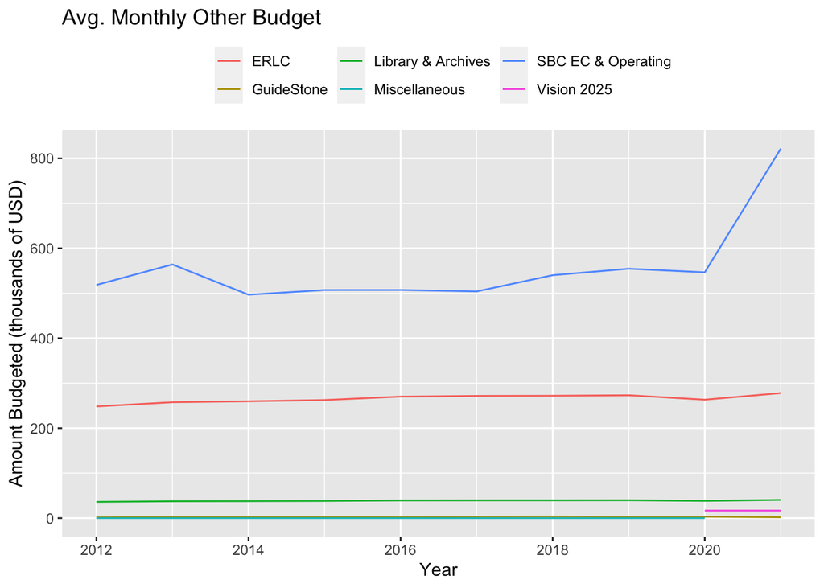